# RGTAN与RGTAN-AFF对比实验

#### 原模型和我改进了一点点的模型实验对比

```python
import os
from argparse import ArgumentParser, ArgumentDefaultsHelpFormatter
from config import Config
from feature_engineering.data_engineering import data_engineer_benchmark, span_data_2d, span_data_3d
import logging
import numpy as np
import pandas as pd
from sklearn.model_selection import train_test_split
import yaml
```

```python
logger = logging.getLogger(__name__)
```

```python
import warnings
warnings.filterwarnings("ignore")
```

```python
def parse_args(method):
    yaml_file = {
        'rgtan-aff': "config/rgtan_aff_cfg.yaml",
    }.get(method, None)

    if not yaml_file:
        raise NotImplementedError(f"Unsupported method: {method}")

    # 读取配置文件
    with open(yaml_file) as file:
        args = yaml.safe_load(file)
    args['method'] = method
    return args
```

```python
def base_load_data(args):
    # 供普通的非图结构的模型使用的S-SSFD
    data_path = "data/S-FFSD.csv"
    feat_df = pd.read_csv(data_path)
    train_size = 1 - args['test_size']

    if os.path.exists("data/tel_2d.npy"):
        return

    features, labels = span_data_2d(feat_df)  # 请确保定义了该函数
    trf, tef, trl, tel = train_test_split(
        features, labels, train_size=train_size, stratify=labels, shuffle=True
    )

    # 保存数据
    np.save(args['trainfeature'], trf)
    np.save(args['testfeature'], tef)
    np.save(args['trainlabel'], trl)
    np.save(args['testlabel'], tel)
```

```python
def main(args):
    if args['method'] == 'rgtan-aff':
        from methods.rgtan_aff.rgtan_aff_main import rgtan_aff_main, loda_rgtan_data
        feat_data, labels, train_idx, test_idx, g, cat_features, neigh_features = loda_rgtan_data(
            args['dataset'], args['test_size'])
        rgtan_aff_main(feat_data, g, train_idx, test_idx, labels, args,
                       cat_features, neigh_features, nei_att_head=args['nei_att_heads'][args['dataset']])
    else:
        raise NotImplementedError("Unsupported method.")
```

### RGTAN-AFF

将TransEmbedding类中添加了一个轻量级的注意力特征融合机制，不再让MLP出来的属性特征直接相加，而是让模型学习一个权重，为每个类别特征的嵌入向量动态地分配一个重要性分数。然后根据这个分数进行加权求和。这样，模型就可以自主地决定在当前交易的上下文中，更关注哪些特征，更细粒度地区分不同类别属性对交易行为的影响力。

##### 注意：下面的训练过程转换成HTML格式之后不能折叠，所以直接拉到最底下开始看

[output not shown]

[output cut: 16253 more lines]

```
In epoch:043|batch:0370, train_loss:0.300673, train_ap:0.8333, train_acc:0.9545, train_auc:0.9474
In epoch:043|batch:0380, train_loss:0.299690, train_ap:1.0000, train_acc:1.0000, train_auc:1.0000
In epoch:043|batch:0000, val_loss:0.407383, val_ap:0.5243, val_acc:0.8462, val_auc:0.7333
In epoch:043|batch:0010, val_loss:0.320428, val_ap:0.7954, val_acc:0.8837, val_auc:0.8738
In epoch:043|batch:0020, val_loss:0.306739, val_ap:0.7461, val_acc:0.8938, val_auc:0.8615
In epoch:043|batch:0030, val_loss:0.294232, val_ap:0.7373, val_acc:0.8991, val_auc:0.8619
In epoch:043|batch:0040, val_loss:0.306231, val_ap:0.7069, val_acc:0.8963, val_auc:0.8433
In epoch:043|batch:0050, val_loss:0.320237, val_ap:0.6921, val_acc:0.8926, val_auc:0.8343
In epoch:043|batch:0060, val_loss:0.318934, val_ap:0.6737, val_acc:0.8938, val_auc:0.8277
In epoch:043|batch:0070, val_loss:0.312261, val_ap:0.6811, val_acc:0.8956, val_auc:0.8345
In epoch:043|batch:0080, val_loss:0.312966, val_ap:0.6821, val_acc:0.8965, val_auc:0.8314
In epoch:043|batch:0090, val_loss:0.307017, val_ap:0.6911, val_acc:0.8982, val_auc:0.8373
EarlyStoper count: 10
Early Stopping!
Best val_loss for fold 5 is: 0.3058455
```

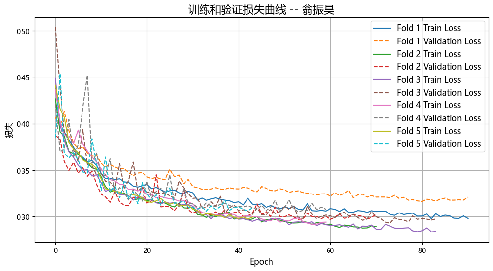

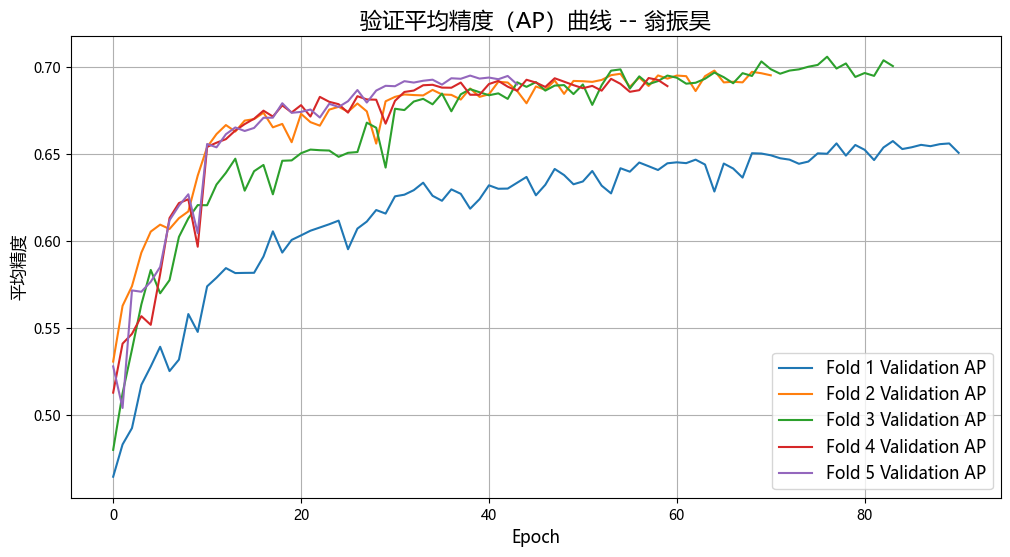

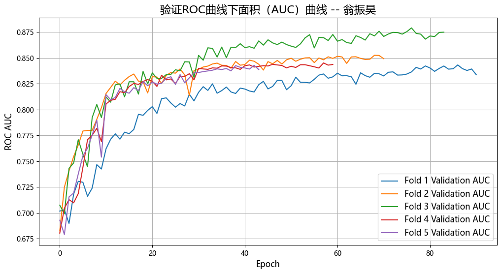

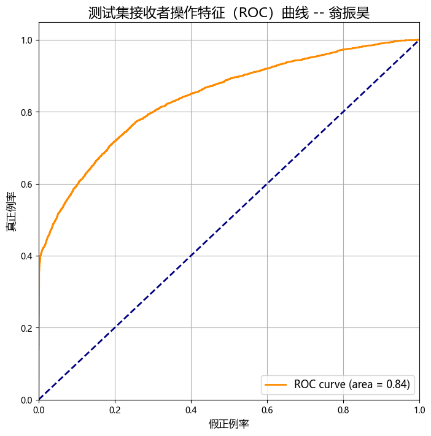

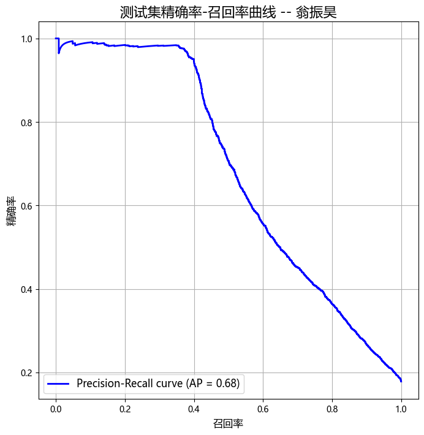

```
NN out of fold AP is: 0.6807343305456945
test AUC: 0.8396743393533272
test AP: 0.6818269207810144
test f1 (macro): 0.7495676689685995
```

```python
method = 'rgtan-aff'
args = parse_args(method)
base_load_data(args)
main(args)
```

#### 从上面的训练过程中的几份图像中可以看到，RGTAN-AFF模型训练过程是健康的，表现也符合预期。模型能够从数据中学习，并且早停机制能够帮助捕获较好的模型状态以防止过拟合。

（3）模型在不同数据划分下均表现出较好的泛化能力。 K-折交叉验证结果共同证实了模型的有效性。

```
Unique model names in df_melted['模型']: ['创新模型 (RGTAN-AFF)' '原模型 (RGTAN)']
```

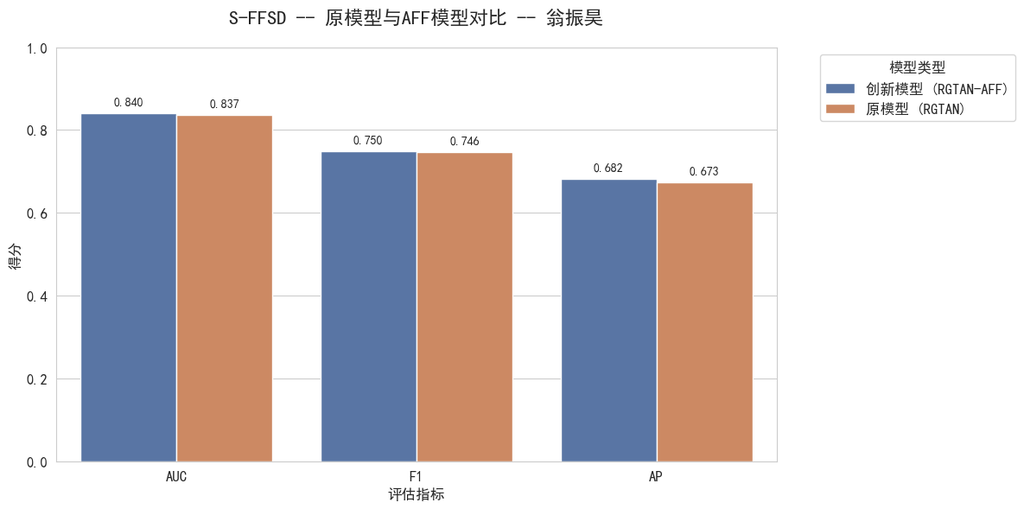

```python
import pandas as pd
import matplotlib.pyplot as plt
import seaborn as sns
from matplotlib import rcParams
import matplotlib.font_manager as fm

# 中文字体配置（确保路径正确）
font_path = 'C:/Windows/Fonts/simhei.ttf'  # Windows系统黑体路径
# 检查字体文件是否存在
try:
    fm.FontProperties(fname=font_path)
except FileNotFoundError:
    print(f"Warning: Font file not found at {font_path}. Using default font.")
    rcParams['font.sans-serif'] = ['sans-serif']
else:
    myfont = fm.FontProperties(fname=font_path, size=12)
    rcParams['font.sans-serif'] = ['SimHei']  # 全局设置
rcParams['axes.unicode_minus'] = False    # 解决负号显示

data = {
    '模型': ['RGTAN-AFF', 'RGTAN'],
    'AUC': [0.8397, 0.8372],
    'F1': [0.7496, 0.7464],
    'AP': [0.6818, 0.6729]
}
df = pd.DataFrame(data)

df['模型'] = df['模型'].replace({
    'RGTAN-AFF': '创新模型 (RGTAN-AFF)',
    'RGTAN': '原模型 (RGTAN)'
})

df_melted = df.melt(id_vars=['模型'],
                    var_name='指标',
                    value_name='得分')

print("Unique model names in df_melted['模型']:", df_melted['模型'].unique())


plt.figure(figsize=(12, 6))
sns.set_style("whitegrid")

ax = sns.barplot(x='指标', y='得分', hue='模型', data=df_melted,
                 palette={'创新模型 (RGTAN-AFF)': '#4C72B0', '原模型 (RGTAN)': '#DD8452'})

plt.title('S-FFSD -- 原模型与AFF模型对比 -- 翁振昊', fontproperties=myfont, fontsize=16, pad=20)
plt.xlabel('评估指标', fontproperties=myfont)
plt.ylabel('得分', fontproperties=myfont)
plt.ylim(0, 1.0)

for p in ax.patches:
    height = p.get_height()
    if height > 0.01: # 忽略接近0的值，确保只标注有效数据
        ax.text(p.get_x() + p.get_width()/2., height + 0.02,
                f'{height:.3f}', ha='center', fontsize=10, fontproperties=myfont)

legend = ax.legend(title='模型类型',
                  bbox_to_anchor=(1.05, 1),
                  loc='upper left',
                  prop=myfont)
legend.get_title().set_fontproperties(myfont)

plt.xticks(fontproperties=myfont)
plt.yticks(fontproperties=myfont)
plt.tight_layout()

# 保存文件名（保持您的要求）
plt.savefig('S-FFSD_原模型与AFF模型对比.png', dpi=300, bbox_inches='tight', facecolor='white')
plt.show()
```

### 实际上的提升确实很有限

- 虽然绝对数值提升不大，但重要的是这种提升是全面且一致的，在所有三个关键指标AUC, F1, AP上都比原始的RGTAN模型取得了微小的提升，这在一定程度上验证我引入注意力特征融合机制来代替普通求和的积极作用。
- RGTAN本身已经是一个针对欺诈检测精心设计的复杂模型，融合了多种有效机制。在强基线模型上取得大幅度提升确实是比较困难。
- 但我想这个小创新还是具备一定价值的，至少有尝试引入了更先进的技术来优化特定模块，虽然没有显式地可视化feature_attention_net的权重，但理论上它可以提供一定的可解释性，帮助理解模型在判断单笔交易时更依赖哪些原始类别特征。

```python
from nbconvert import HTMLExporter
import nbformat

# 加载notebook文件
with open('RGTAN-AFF_exp_wengzhenhao.ipynb') as f:
    nb = nbformat.read(f, as_version=4)

html_exporter = HTMLExporter()
html, resources = html_exporter.from_notebook_node(nb)

# 写入HTML文件
with open('RGTAN-AFF_exp_wengzhenhao.html', 'w') as f:
    f.write(html)
```